# Becsléselmélet

## Binomiálissal való közelítés

Ha kicsi a minta, még ha visszatevéses is a mintavétel, aligha kerül be valaki kétszer

\[E(\xi)=p\] \[D(\xi)=\sqrt{\frac{n* p*(1-p)}{n^2}}\]

## Binomiálissal való közelítés

Ha kicsi a minta, még ha visszatevéses is a mintavétel, aligha kerül be valaki kétszer

\[E(\xi)=p\] \[D(\xi)=\sqrt{\frac{p*(1-p)}{n}}\]

## Normális eloszlással való közelítés

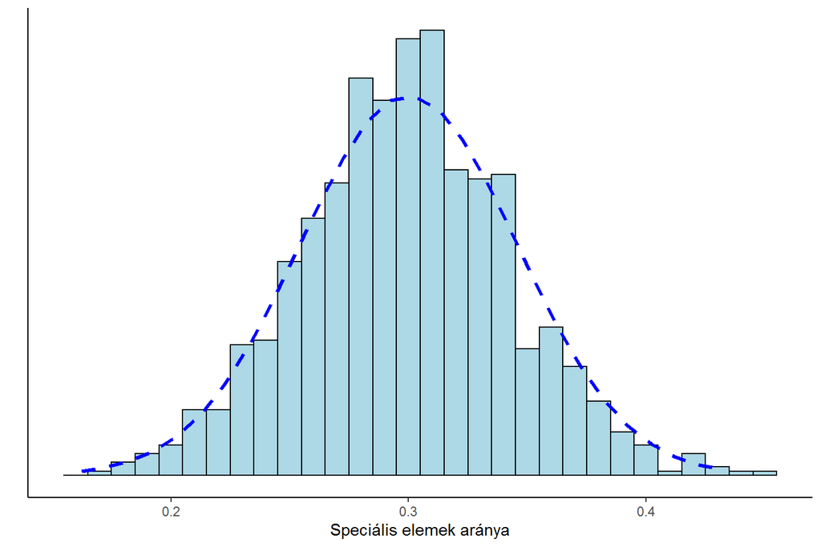

## Intervallumbecslés az arányra

Általános képlet:

pontbecslés ± valahányszor a st. hiba

Alkalmazva az arányra: \[p \pm z_{1-\frac{\alpha}{2}}*\sqrt{\frac{p*(1-p)}{N}}\]

## Intervallumbecslés arányra: feladatok

- \(N=200; p=0.25; 1-\alpha=0.95\)
- \(N=100; p=0.50; 1-\alpha=0.90\)
- \(N=1000; p=0.60; 1-\alpha=0.99\)

## Intervallumbecslés: 1. feladat

\[p \pm z_{1-\frac{\alpha}{2}}*\sqrt{\frac{p*(1-p)}{N}}\]

\[0.25 \pm 1.96*\sqrt{\frac{0.25*(1-0.25)}{200}}=?\]

## Intervallumbecslés: 1. feladat

\[p \pm z_{1-\frac{\alpha}{2}}*\sqrt{\frac{p*(1-p)}{N}}\]

\[0.25 \pm 1.96*\sqrt{\frac{0.25*(1-0.25)}{200}}=0.25 \pm 0.060\]

## Intervallumbecslés: 1. feladat

\[p \pm z_{1-\frac{\alpha}{2}}*\sqrt{\frac{p*(1-p)}{N}}\]

\[0.25 \pm 1.96*\sqrt{\frac{0.25*(1-0.25)}{200}}= [0.190; 0.310]\]

## Intervallumbecslés: 2. feladat

\[p \pm z_{1-\frac{\alpha}{2}}*\sqrt{\frac{p*(1-p)}{N}}\]

\[0.50 \pm 1.65*\sqrt{\frac{0.50*(1-0.50)}{100}}=?\]

## Intervallumbecslés: 2. feladat

\[p \pm z_{1-\frac{\alpha}{2}}*\sqrt{\frac{p*(1-p)}{N}}\]

\[0.50 \pm 1.65*\sqrt{\frac{0.50*(1-0.50)}{100}}=0.50 \pm 0.082\]

## Intervallumbecslés: 2. feladat

\[p \pm z_{1-\frac{\alpha}{2}}*\sqrt{\frac{p*(1-p)}{N}}\]

\[0.50 \pm 1.65*\sqrt{\frac{0.50*(1-0.50)}{100}}= [0.417; 0.583]\]

## Intervallumbecslés: 3. feladat

\[p \pm z_{1-\frac{\alpha}{2}}*\sqrt{\frac{p*(1-p)}{N}}\]

\[0.60 \pm 2.58*\sqrt{\frac{0.60*(1-0.60)}{1000}}=?\]

## Intervallumbecslés: 3. feladat

\[p \pm z_{1-\frac{\alpha}{2}}*\sqrt{\frac{p*(1-p)}{N}}\]

\[0.60 \pm 2.58*\sqrt{\frac{0.60*(1-0.60)}{1000}}=0.60 \pm 0.040\]

## Intervallumbecslés: 3. feladat

\[p \pm z_{1-\frac{\alpha}{2}}*\sqrt{\frac{p*(1-p)}{N}}\]

\[0.60 \pm 2.58*\sqrt{\frac{0.60*(1-0.60)}{1000}}= [0.560; 0.640]\]

## Legfontosabb tudnivalók

Intervallumbecslés lényege:

- a pontbecslés alapján megadunk egy intervallumot (**konfidenciaintervallum**),
- amelybe a becsülni kívánt **populációs** paraméter
- megadott valószínűséggel (**konfidenciaszint**) beleesik (általában \(1-\alpha=0.95\))

Hogyan?

- A pontbecslésből kivonjuk és hozzáadjuk a becslés szórásának (**standard hibájának**) valahányszorosát
- Azt, hogy hányszorosát, a standard normális vagy a Student-féle t-eloszlás táblázatából olvassuk ki

## Legfontosabb tudnivalók

Intervallumbecslés átlagra:

- Ha ismert az elméleti szórás: \(\overline{X}\pm z_{1-\frac{\alpha}{2}}*\frac{\sigma}{\sqrt{N}}\)
- Ha a szórást becsüljük: \(\overline{X}\pm t_{df;1-\frac{\alpha}{2}}*\frac{s^*}{\sqrt{N}}\)

Intervallumbecslés arányra:

- \(p \pm z_{1-\frac{\alpha}{2}}*\sqrt{\frac{p*(1-p)}{N}}\)

Az intervallum hossza függ:

- konfidenciaszint ⇒ \(z_{1-\frac{\alpha}{2}} / t_{df;1-\frac{\alpha}{2}}\)
- szórás / arány (max. 0,5-nél)
- mintanagyság